**Deep Learning for Mechanical Engineering**  
**Midterm Exam**  
**October 25th 2022, 9:00 PM to 11:00 PM (120 minutes)**

TA: Jaejung Park  
Instructor: Prof. Seungchul Lee  
http://iai.postech.ac.kr/  
Industrial AI Lab at POSTECH

# Problem 1: Rotating Machinery Diagnosis

Mechanical systems are always vibrating when operating. So, vibration analysis is one of the most popular and conventional ways to diagnose the mechanical system. In this problem, we are going to use the logistic regression algorithm to identify abnormality of a mechanical system.

**Data information**

- File format: npy
- Information: signal, label
- Sampling rate: 12,800 Hz
- File length (time): 0.78 sec
- Labels based on one-hot encoding
  - A (Normal): [1,0]
  - B (Abnormal): [0,1]

**Data Download Link**

- [data](https://www.dropbox.com/s/3t79yd2e03fkteg/signal.npy?dl=1)
- [label](https://www.dropbox.com/s/4jr4g1sw8b38us6/label.npy?dl=1)

```python
import numpy as np
import matplotlib.pyplot as plt
import tensorflow as tf
import IPython.display as ipd
import scipy.stats
import scipy
from sklearn.model_selection import train_test_split
%matplotlib inline


# Function for reproducibility
def Random(seed_value):
    import os
    os.environ['PYTHONHASHSEED'] = str(seed_value)

    import random
    random.seed(seed_value)

    import numpy as np
    np.random.seed(seed_value)

    import tensorflow as tf
    tf.random.set_seed(seed_value)

Random(0)
```

```python
# data load
data = {
    'signal': np.load('signal.npy'),
    'label': np.load('label.npy')
}
```

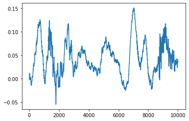

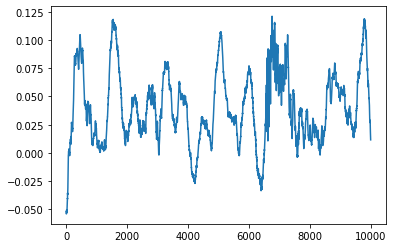

```python
N = 2000

for _ in range(2):
    i = np.random.randint(N)
    plt.plot(data['signal'][i])
    plt.show()
```

Now, we need to extract features from the raw signal.

- Use the following statistical features
  - peak, rms, kurtosis, crest factor, impulse factor, shape factor, skewness, smr, peak-peak

The equations are as follows:

$$\begin{align*} \text{Peak Value } &= \max_{n = 1, \dots, N} x_n \\ \\ \text{RMS } &= \sqrt{\frac{1}{N}\sum_{n=1}^N x_n^2} \\ \\ \text{Kurtosis } &= \frac{\frac{1}{N}\sum_{n=1}^N (x_n-\bar{x})^4}{\text{Var}^2} \\ \\ \text{Var } &= \frac{1}{N}\sum_{n=1}^N (x_n-\bar{x})^2 \\\\ \text{Crest Factor } &= \frac{\text{Peak}}{\text{RMS}}\\\\ \text{Impulse Factor } &= \frac{\text{Peak}}{\text{Mean}} \\ \\ \text{Mean } &= \frac{1}{N}\sum_{n=1}^N \lvert x_n \rvert \\\\ \text{Shape Factor } &= \frac{\text{RMS}}{\text{Mean}}\\\\ \text{Skewness } &= \frac{\frac{1}{N}\sum_{n=1}^N(x_n-\bar{x})^3}{\text{Var}^{3/2}}\\\\ \text{SMR } &= \left(\frac{1}{N}\sum_{n=1}^N\sqrt{x_n} \right)^2 \\\\ \text{Peak-Peak Value } &= \max_{n = 1, \dots, N} x_n-\min_{n = 1, \dots, N} x_n \end{align*}$$$$x_i: \text{signal data}$$

The function for feature extraction is already ready for you. The function input and output are data $x$ and horizontally stacked feature vector, respectively.

```python
def extfeat(x):
    fvector = []

    # time domain feature
    peak = np.max(np.abs(x))
    fvector.append(peak)

    rms = np.sqrt(np.mean(x**2))
    fvector.append(rms)

    kurtosis = scipy.stats.kurtosis(x)
    fvector.append(kurtosis)

    crest_factor = fvector[0]/fvector[1]
    fvector.append(crest_factor)

    impulse_factor = fvector[0]/(np.sum(np.abs(x))/len(x))
    fvector.append(impulse_factor)

    shape_factor = fvector[1]/(np.sum(np.abs(x))/len(x))
    fvector.append(shape_factor)

    skewness = scipy.stats.skew(x)
    fvector.append(skewness)

    smr = (np.sum(np.sqrt(np.abs(x)))/len(x))**2
    fvector.append(smr)

    pp = np.max(x) - np.min(x)
    fvector.append(pp)

    return fvector

feature_name = ['Peak', 'RMS', 'Kurtosis', 'Crest Factor', 'Impulse Factor','Shape Factor','Skewness','SMR', 'Peak-Peak']
```

```python
all_data = []
for i in range(len(data['label'])):
    d = extfeat(data['signal'][i])
    all_data.append(d)

all_data = np.array(all_data)

tr_data, te_data, tr_label, te_label = train_test_split(all_data, data['label'], test_size = 1/4, shuffle=True, random_state=42)
```

1) Design your logistic regression model using `scikit learn` library and train it.

```python
# Your code here
#
from sklearn.linear_model import LogisticRegression

clf = LogisticRegression().fit(tr_data, np.ravel(tr_label))
```

2) Compute the accuracy for test dataset.

```python
# Your code here
#
pred = clf.predict(te_data)
```

```python
my_pred = pred
labels  = te_label
accr = np.mean(np.equal(my_pred, labels.ravel()))
print("Accuracy : {}%".format(accr*100))
```

```
Accuracy : 97.8%
```

3) Design an autoencoder model with the same structure as shown in the figure below and train it.

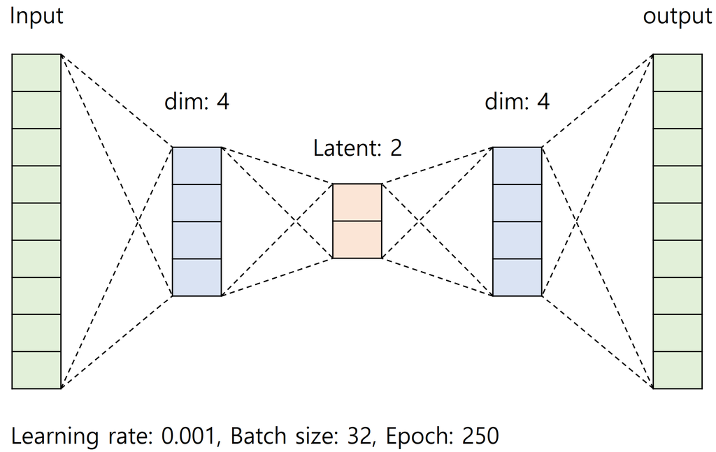

```python
# Your code here
#
# Encoder Structure
encoder = tf.keras.models.Sequential([
    tf.keras.layers.Dense(4, activation = 'relu', input_shape = (9,)),
    tf.keras.layers.Dense(2, activation = None)
    ])

# Decoder Structure
decoder = tf.keras.models.Sequential([
    tf.keras.layers.Dense(4, activation = 'relu', input_shape = (2,)),
    tf.keras.layers.Dense(9, activation = None)
    ])

# Autoencoder = Encoder + Decoder
autoencoder = tf.keras.models.Sequential([encoder, decoder])
```

```python
autoencoder.compile(optimizer = tf.keras.optimizers.Adam(0.001),
                    loss = 'mean_squared_error',
                    metrics = ['mse'])
```

```python
training = autoencoder.fit(tr_data, tr_data, batch_size =32, epochs = 250)
```

4) Compute MSE loss for the reconstructed test dataset.

```python
# Your code here
#
test_scores = autoencoder.evaluate(te_data, te_data, verbose = 2)
print('Test loss: {}'.format(test_scores[0]))
print('Mean Squared Error: {} %'.format(test_scores[1]*100))
```

```
16/16 - 0s - loss: 0.0103 - mse: 0.0103
Test loss: 0.01026862021535635
Mean Squared Error: 1.026862021535635 %
```

5) Plotting the latent variable for the train dataset.

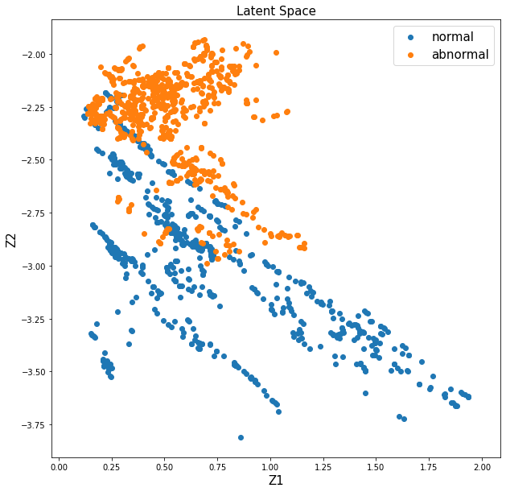

```python
# Your code here
#
latent = encoder.predict(tr_data)

plt.figure(figsize = (10,10))
plt.scatter(latent[tr_label == 0, 0], latent[tr_label == 0, 1], label = 'normal')
plt.scatter(latent[tr_label == 1, 0], latent[tr_label == 1, 1], label = 'abnormal')
plt.title('Latent Space', fontsize=15)
plt.xlabel('Z1', fontsize=15)
plt.ylabel('Z2', fontsize=15)
plt.legend(fontsize = 15)
plt.axis('equal')
plt.show()
```

6) Design a logistic regression model to find a straight line that split normal and abnormal in the latent space.

```python
## Your code here
#
from sklearn import linear_model

clf = linear_model.LogisticRegression()
clf.fit(latent, tr_label)
```

```
LogisticRegression()
```

7) Plotting test dataset in the latent space and straight line that split normal and abnormal.

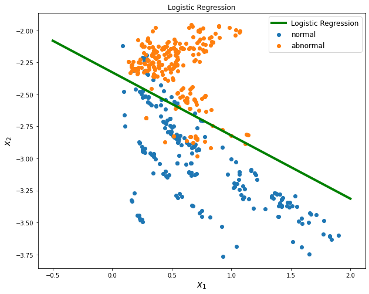

```python
# Your code here
#
test_latent = encoder.predict(te_data)
w0 = clf.intercept_[0]
w1 = clf.coef_[0,0]
w2 = clf.coef_[0,1]

xp = np.linspace(-0.5, 2,100).reshape(-1,1)
yp = - w1/w2*xp - w0/w2

plt.figure(figsize = (10,8))
plt.scatter(test_latent[te_label == 0, 0], test_latent[te_label == 0, 1], label = 'normal')
plt.scatter(test_latent[te_label == 1, 0], test_latent[te_label == 1, 1], label = 'abnormal')
plt.plot(xp, yp, 'g', linewidth = 4, label = 'Logistic Regression')
plt.title('Logistic Regression')
plt.xlabel(r'$x_1$', fontsize = 15)
plt.ylabel(r'$x_2$', fontsize = 15)
plt.legend(loc = 1, fontsize = 12)
plt.axis('auto')
plt.show()
```

8) Compute the accuracy for test dataset in the latent space.

```python
# Your code here
#
test_8 = encoder.predict(te_data)

print('Accuracy {:.2f}%'.format(clf.score(test_8,te_label)*100))
```

```
Accuracy 90.80%
```

# Problem 2: Data Augmentation with CVAE

**This problem is to show that CVAE can be used for the data generation**

1) Load the MNIST dataset

- Training Data: For each digit, we use first 100 images (100 images per digit). So you will have 1000 images in total for this problem as a training dataset
- Test Data: For the test dataset, we use first 20 images for each digit. So you will have 200 images as a test dataset.
- Downlaod [CVAE training image.npy](https://www.dropbox.com/s/0wggj36dnhb7axk/CVAE%20training%20image.npy?dl=1)
- Downlaod [CVAE training label.npy](https://www.dropbox.com/s/5atrolw6bsu7n1e/CVAE%20training%20label.npy?dl=1)
- Downlaod [CVAE test image.npy](https://www.dropbox.com/s/4fn05puenv13n0a/CVAE%20test%20image.npy?dl=1)
- Downlaod [CVAE test label.npy](https://www.dropbox.com/s/vckfgx4e545s9vb/CVAE%20test%20label.npy?dl=1)

```python
import numpy as np
import matplotlib.pyplot as plt
import tensorflow as tf
tf.compat.v1.disable_eager_execution()

# Your code here
#
train_i=np.load('CVAE training image.npy')
train_label=np.load('CVAE training label.npy')
test_i=np.load('CVAE test image.npy')
test_label=np.load('CVAE test label.npy')
```

2) Train a model on the dataset

- Plot the training and validation curve and report the test accuracy
- Create the base model with just single layer perceptron without any hidden layers! (Only one Dense layer is allowed)
- Use SGD optimizer with learning rate of 0.001 and 'sparse_categorical_crossentropy' loss
- Maximum epochs: 20
- Your test accuracy is supposed to be low due to small size of the training data set! Do not worry about low accuracy.

```python
# Your code here for the model
#
model = tf.keras.Sequential([
    tf.keras.layers.Flatten(input_shape=(28, 28)),
    tf.keras.layers.Dense(units=10, activation='softmax')
])

model.compile(optimizer = tf.keras.optimizers.SGD(learning_rate=0.001),
              loss='sparse_categorical_crossentropy',
              metrics=['accuracy'])

model.summary()
```

```
WARNING:tensorflow:From c:\users\parkf\appdata\local\programs\python\python36\lib\site-packages\tensorflow\python\ops\resource_variable_ops.py:1666: calling BaseResourceVariable.__init__ (from tensorflow.python.ops.resource_variable_ops) with constraint is deprecated and will be removed in a future …
Instructions for updating:
If using Keras pass *_constraint arguments to layers.
Model: "sequential"
_________________________________________________________________
Layer (type)                 Output Shape              Param #
=================================================================
flatten (Flatten)            (None, 784)               0
_________________________________________________________________
dense (Dense)                (None, 10)                7850
=================================================================
Total params: 7,850
Trainable params: 7,850
Non-trainable params: 0
_________________________________________________________________
```

```python
# Your code here for the training the model
#
history = model.fit(train_i, train_label, epochs = 20, batch_size = 32)
```

```
Train on 1000 samples
```

```python
result=model.evaluate(test_i,test_label, batch_size=36)
print(result)
```

```
[1.8400955319404602, 0.51]
```

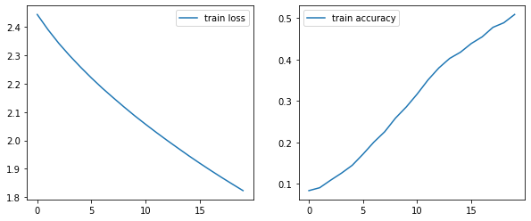

```
Test accuracy is :  0.51
```

```python
loss = history.history['loss']
accuracy = history.history['accuracy']


xrange = range(20)
plt.figure(figsize=(10,4))
plt.subplot(1,2,1)
plt.plot(xrange, loss, label = 'train loss')

plt.legend()
plt.subplot(1,2,2)
plt.plot(xrange, accuracy, label = 'train accuracy')

plt.legend()
plt.show()
print('Test accuracy is : ', result[1])
```

Now, we want to generate new data with CVAE (Conditional Variational Autoencoder) !

3) Define the structure, loss, and model of the CVAE and train the CVAE.

'Variational' part is given below. (Refer to Problem 2 in PS#06)

```python
# Your code here for the structure of CVAE
#
n_pixels = np.prod(train_i.shape[1:])
train_ii = train_i.reshape((len(train_i), n_pixels))
test_ii = test_i.reshape((len(test_i), n_pixels))
train_labeli = tf.keras.utils.to_categorical(train_label)
test_labeli = tf.keras.utils.to_categorical(test_label)
n_x = train_ii.shape[1]
n_y = train_labeli.shape[1]
# Define the input
#
X = tf.keras.layers.Input(shape=(n_x,))
label = tf.keras.layers.Input(shape=(n_y,))
inputs = tf.keras.layers.concatenate([X,label])


# Define encoder
#
encoder_h = tf.keras.layers.Dense(512, activation='relu')(inputs)
mu = tf.keras.layers.Dense(2, activation='linear')(encoder_h)
l_sigma = tf.keras.layers.Dense(2, activation='linear')(encoder_h)


# Sampling latent space (you may change the code below so that the function fits your variables)
def sample_z(args): # a function that adds random normal noise -'variational' part
    mu, l_sigma = args
    eps = tf.keras.backend.random_normal(shape=(50, 2), mean=0., stddev=1.)
    return mu + tf.keras.backend.exp(l_sigma / 2) * eps

z = tf.keras.layers.Lambda(sample_z, output_shape = (2, ))([mu, l_sigma])
zc = tf.keras.layers.concatenate([z, label])

# Define decoder
#
decoder_hidden =  tf.keras.layers.Dense(512, activation='relu')
decoder_out =  tf.keras.layers.Dense(784, activation='sigmoid')
h_p = decoder_hidden(zc)
outputs = decoder_out(h_p)
```

```python
# Your code here for the loss of CVAE
#
def cae_loss(y_true, y_pred):
    recon = tf.keras.backend.sum(tf.keras.backend.binary_crossentropy(y_true, y_pred), axis=-1) # what will be the reconstruction error?
    kl = 0.5 * tf.keras.backend.sum(tf.keras.backend.exp(l_sigma) + tf.keras.backend.square(mu) - 1. - l_sigma, axis=-1) #you don't have to worry about this part
    return recon + kl
```

```python
# Your code here for the entire model of CVAE
#
cvae = tf.keras.models.Model([X, label], outputs)
encoder = tf.keras.models.Model([X, label], mu)

d_in = tf.keras.layers.Input(shape=(2+n_y,))
d_h = decoder_hidden(d_in)
d_out = decoder_out(d_h)
decoder = tf.keras.models.Model(d_in, d_out)
```

```python
# Your code here for the training of CVAE
#
cvae.compile(optimizer=tf.keras.optimizers.Adam(lr=0.001), loss=cae_loss)
cvae_hist = cvae.fit([train_ii, train_labeli], train_ii, verbose = 1, batch_size=50, epochs=500)
```

```
Train on 1000 samples
```

4) Generate 400 new images for each digit by using the condition (providing a label to the decoder) and add the generated images into the training dataset

- You should have 5000 images in the training dataset after the data generation

```python
# Your code here
#
def construct_numvec(digit, z = None):
    out = np.zeros((1, 2 + n_y))
    out[:, digit + 2] = 1.
    if z is None:
        return(out)
    else:
        for i in range(len(z)):
            out[:,i] = z[i]
        return(out)
```

[figure not shown]

```python
add1=np.zeros((400,28,28))
add1_label=np.full(400,1)
dig = 1
sides = 20
max_z = 0.6

img_it = 0
num=0
for i in range(0, sides):
    z1 = (((i / (sides-1)) * max_z)*2) - max_z
    for j in range(0, sides):
        z2 = (((j / (sides-1)) * max_z)*2) - max_z
        z_ = [z1, z2]
        vec = construct_numvec(dig, z_)
        decoded = decoder.predict(vec)
        plt.subplot(sides, sides, 1 + img_it)
        img_it +=1
        plt.axis('off')
        plt.imshow(decoded.reshape(28, 28), cmap = plt.cm.gray)
        add1[num]=decoded.reshape(28,28)
        num=num+1
plt.subplots_adjust(left=0, bottom=0, right=1, top=1, wspace=0, hspace=.2)

plt.show()
```

[figure not shown]

```python
add2=np.zeros((400,28,28))
add2_label=np.full(400,2)
dig = 2
sides = 20
max_z = 0.6

img_it = 0
num=0
for i in range(0, sides):
    z1 = (((i / (sides-1)) * max_z)*2) - max_z
    for j in range(0, sides):
        z2 = (((j / (sides-1)) * max_z)*2) - max_z
        z_ = [z1, z2]
        vec = construct_numvec(dig, z_)
        decoded = decoder.predict(vec)
        plt.subplot(sides, sides, 1 + img_it)
        img_it +=1
        plt.axis('off')
        plt.imshow(decoded.reshape(28, 28), cmap = plt.cm.gray)
        add2[num]=decoded.reshape(28,28)
        num=num+1
plt.subplots_adjust(left=0, bottom=0, right=1, top=1, wspace=0, hspace=.2)

plt.show()
```

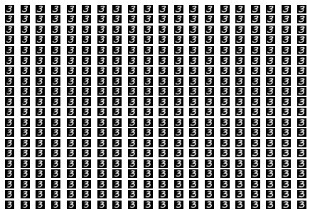

```python
add3=np.zeros((400,28,28))
add3_label=np.full(400,3)
dig = 3
sides = 20
max_z = 0.6

img_it = 0
num=0
for i in range(0, sides):
    z1 = (((i / (sides-1)) * max_z)*2) - max_z
    for j in range(0, sides):
        z2 = (((j / (sides-1)) * max_z)*2) - max_z
        z_ = [z1, z2]
        vec = construct_numvec(dig, z_)
        decoded = decoder.predict(vec)
        plt.subplot(sides, sides, 1 + img_it)
        img_it +=1
        plt.axis('off')
        plt.imshow(decoded.reshape(28, 28), cmap = plt.cm.gray)
        add3[num]=decoded.reshape(28,28)
        num=num+1
plt.subplots_adjust(left=0, bottom=0, right=1, top=1, wspace=0, hspace=.2)

plt.show()
```

[figure not shown]

```python
add4=np.zeros((400,28,28))
add4_label=np.full(400,4)
dig = 4
sides = 20
max_z = 0.6

img_it = 0
num=0
for i in range(0, sides):
    z1 = (((i / (sides-1)) * max_z)*2) - max_z
    for j in range(0, sides):
        z2 = (((j / (sides-1)) * max_z)*2) - max_z
        z_ = [z1, z2]
        vec = construct_numvec(dig, z_)
        decoded = decoder.predict(vec)
        plt.subplot(sides, sides, 1 + img_it)
        img_it +=1
        plt.axis('off')
        plt.imshow(decoded.reshape(28, 28), cmap = plt.cm.gray)
        add4[num]=decoded.reshape(28,28)
        num=num+1
plt.subplots_adjust(left=0, bottom=0, right=1, top=1, wspace=0, hspace=.2)

plt.show()
```

[figure not shown]

```python
add5=np.zeros((400,28,28))
add5_label=np.full(400,5)
dig = 5
sides = 20
max_z = 0.6

img_it = 0
num=0
for i in range(0, sides):
    z1 = (((i / (sides-1)) * max_z)*2) - max_z
    for j in range(0, sides):
        z2 = (((j / (sides-1)) * max_z)*2) - max_z
        z_ = [z1, z2]
        vec = construct_numvec(dig, z_)
        decoded = decoder.predict(vec)
        plt.subplot(sides, sides, 1 + img_it)
        img_it +=1
        plt.axis('off')
        plt.imshow(decoded.reshape(28, 28), cmap = plt.cm.gray)
        add5[num]=decoded.reshape(28,28)
        num=num+1
plt.subplots_adjust(left=0, bottom=0, right=1, top=1, wspace=0, hspace=.2)

plt.show()
```

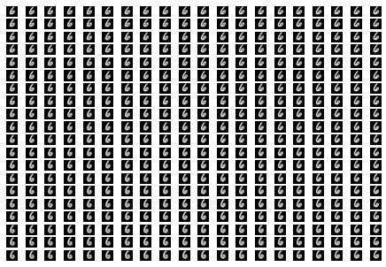

```python
add6=np.zeros((400,28,28))
add6_label=np.full(400,6)
dig = 6
sides = 20
max_z = 0.6

img_it = 0
num=0
for i in range(0, sides):
    z1 = (((i / (sides-1)) * max_z)*2) - max_z
    for j in range(0, sides):
        z2 = (((j / (sides-1)) * max_z)*2) - max_z
        z_ = [z1, z2]
        vec = construct_numvec(dig, z_)
        decoded = decoder.predict(vec)
        plt.subplot(sides, sides, 1 + img_it)
        img_it +=1
        plt.axis('off')
        plt.imshow(decoded.reshape(28, 28), cmap = plt.cm.gray)
        add6[num]=decoded.reshape(28,28)
        num=num+1
plt.subplots_adjust(left=0, bottom=0, right=1, top=1, wspace=0, hspace=.2)

plt.show()
```

[figure not shown]

```python
add7=np.zeros((400,28,28))
add7_label=np.full(400,7)
dig = 7
sides = 20
max_z = 0.6

img_it = 0
num=0
for i in range(0, sides):
    z1 = (((i / (sides-1)) * max_z)*2) - max_z
    for j in range(0, sides):
        z2 = (((j / (sides-1)) * max_z)*2) - max_z
        z_ = [z1, z2]
        vec = construct_numvec(dig, z_)
        decoded = decoder.predict(vec)
        plt.subplot(sides, sides, 1 + img_it)
        img_it +=1
        plt.axis('off')
        plt.imshow(decoded.reshape(28, 28), cmap = plt.cm.gray)
        add7[num]=decoded.reshape(28,28)
        num=num+1
plt.subplots_adjust(left=0, bottom=0, right=1, top=1, wspace=0, hspace=.2)

plt.show()
```

[figure not shown]

```python
add8=np.zeros((400,28,28))
add8_label=np.full(400,8)
dig = 8
sides = 20
max_z = 0.6

img_it = 0
num=0
for i in range(0, sides):
    z1 = (((i / (sides-1)) * max_z)*2) - max_z
    for j in range(0, sides):
        z2 = (((j / (sides-1)) * max_z)*2) - max_z
        z_ = [z1, z2]
        vec = construct_numvec(dig, z_)
        decoded = decoder.predict(vec)
        plt.subplot(sides, sides, 1 + img_it)
        img_it +=1
        plt.axis('off')
        plt.imshow(decoded.reshape(28, 28), cmap = plt.cm.gray)
        add8[num]=decoded.reshape(28,28)
        num=num+1
plt.subplots_adjust(left=0, bottom=0, right=1, top=1, wspace=0, hspace=.2)

plt.show()
```

[figure not shown]

```python
add9=np.zeros((400,28,28))
add9_label=np.full(400,9)
dig = 9
sides = 20
max_z = 0.6

img_it = 0
num=0
for i in range(0, sides):
    z1 = (((i / (sides-1)) * max_z)*2) - max_z
    for j in range(0, sides):
        z2 = (((j / (sides-1)) * max_z)*2) - max_z
        z_ = [z1, z2]
        vec = construct_numvec(dig, z_)
        decoded = decoder.predict(vec)
        plt.subplot(sides, sides, 1 + img_it)
        img_it +=1
        plt.axis('off')
        plt.imshow(decoded.reshape(28, 28), cmap = plt.cm.gray)
        add9[num]=decoded.reshape(28,28)
        num=num+1
plt.subplots_adjust(left=0, bottom=0, right=1, top=1, wspace=0, hspace=.2)

plt.show()
```

[figure not shown]

```python
add0=np.zeros((400,28,28))
add0_label=np.full(400,0)
dig = 0
sides = 20
max_z = 0.6

img_it = 0
num=0
for i in range(0, sides):
    z1 = (((i / (sides-1)) * max_z)*2) - max_z
    for j in range(0, sides):
        z2 = (((j / (sides-1)) * max_z)*2) - max_z
        z_ = [z1, z2]
        vec = construct_numvec(dig, z_)
        decoded = decoder.predict(vec)
        plt.subplot(sides, sides, 1 + img_it)
        img_it +=1
        plt.axis('off')
        plt.imshow(decoded.reshape(28, 28), cmap = plt.cm.gray)
        add0[num]=decoded.reshape(28,28)
        num=num+1
plt.subplots_adjust(left=0, bottom=0, right=1, top=1, wspace=0, hspace=.2)

plt.show()
```

```python
train_img =np.concatenate([train_i,add1,add2,add3,add4,add5,add6,add7,add8,add9,add0],axis=0)
train_label =np.concatenate([train_label,add1_label,add2_label,add3_label,add4_label,add5_label,add6_label,add7_label,add8_label,add9_label,add0_label],axis=0)
```

5) Using the augmented dataset composed in the section 4), train new model with the same structure and parameters with the model in the section 2) and compare the test accuracy

```python
# Your code here
#
model2 = tf.keras.Sequential([
    tf.keras.layers.Flatten(input_shape=(28, 28)),
    tf.keras.layers.Dense(units=10, activation='softmax')
])

model2.compile(optimizer = tf.keras.optimizers.SGD(learning_rate=0.001),
              loss='sparse_categorical_crossentropy',
              metrics=['accuracy'])

model2.summary()
```

```
Model: "sequential_1"
_________________________________________________________________
Layer (type)                 Output Shape              Param #
=================================================================
flatten_1 (Flatten)          (None, 784)               0
_________________________________________________________________
dense_6 (Dense)              (None, 10)                7850
=================================================================
Total params: 7,850
Trainable params: 7,850
Non-trainable params: 0
_________________________________________________________________
```

```python
history2 = model2.fit(train_img, train_label, epochs = 20, batch_size = 32)
```

```
Train on 5000 samples
```

```python
result2=model2.evaluate(test_i,test_label, batch_size=32)
print(result2)
```

```
[1.077176465988159, 0.715]
```

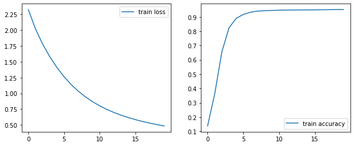

```
Test accuracy is :  0.715
```

```python
loss = history2.history['loss']
accuracy = history2.history['accuracy']


xrange = range(20)
plt.figure(figsize=(10,4))
plt.subplot(1,2,1)
plt.plot(xrange, loss, label = 'train loss')

plt.legend()
plt.subplot(1,2,2)
plt.plot(xrange, accuracy, label = 'train accuracy')

plt.legend()
plt.show()
print('Test accuracy is : ', result2[1])
```

```python
print(result)
print(result2)
```

```
[1.8400955319404602, 0.51]
[1.077176465988159, 0.715]
```

# Problem 3: Data Defect

**This problem is to demonstrate the importance of the class activation map**

Let's consider a situation. Prof. Lee wanted a deep learning model that classifies digit '7' and '9'. However, when the student A was collecting image data for those two digits, some malfunction happened and resulted defects on all digit '9' images. Unforetunately, student A had no idea that his collected data had defects and trained the model with that data. After training his model, he achieved over 90% accuracy in the binary classification with his validation dataset. So, he gave the model to Prof. Lee. Prof. Lee with his own data that have no defects, testsed the model made by the student A. The model's test accuracy was very low! Such situation happened because the student A never plotted the class activation map for his validation dataset. The student A should have checked the region where the model focuses on when making the classification decision.

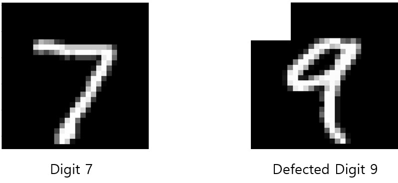

1) Load the training dataset provided above

- Download [CAM defect train image.npy](https://www.dropbox.com/s/mza3bvtdevowdsg/CAM%20defect%20train%20image.npy?dl=1)
- Download [CAM defect train label.npy](https://www.dropbox.com/s/0mvk7lsel1bvro6/CAM%20defect%20train%20label.npy?dl=1)
- Seperate the training dataset into train:validation in the ratio of 9:1
- Provided dataset is composed of MNIST images from two different classes

```python
# Your code here
#
import numpy as np
import matplotlib.pyplot as plt
import tensorflow as tf
import sklearn
from sklearn.model_selection import train_test_split
train_img=np.load('CAM defect train image.npy')
train_label=np.load('CAM defect train label.npy')
train_i, val_i, train_l, val_l=train_test_split(train_img, train_label, test_size=0.1, random_state=42)
```

2) Design your CNN structure for the binary and train your model

- You must not report the test accuracy since test dataset is not provided yet

```python
# Your code here
#
model = tf.keras.models.Sequential([
    tf.keras.layers.Conv2D(filters = 32,
                           kernel_size = (3,3),
                           activation = 'relu',
                           padding = 'SAME',
                           input_shape = (28, 28, 1)),

    tf.keras.layers.MaxPool2D((2,2)),

    tf.keras.layers.Conv2D(filters = 64,
                           kernel_size = (3,3),
                           activation = 'relu',
                           padding = 'SAME',
                           input_shape = (14, 14, 32)),

    tf.keras.layers.MaxPool2D((2,2)),

    tf.keras.layers.Conv2D(filters = 128,
                        kernel_size = (3,3),
                        activation = 'relu',
                        padding = 'SAME',
                        input_shape = (7, 7, 64)),

    tf.keras.layers.MaxPool2D((2,2)),

    tf.keras.layers.Flatten(),

    tf.keras.layers.Dense(units = 128, activation = 'relu'),

    tf.keras.layers.Dense(units = 2, activation = 'softmax')
])
model.summary()
```

```
Model: "sequential_2"
_________________________________________________________________
Layer (type)                 Output Shape              Param #
=================================================================
conv2d (Conv2D)              (None, 28, 28, 32)        320
_________________________________________________________________
max_pooling2d (MaxPooling2D) (None, 14, 14, 32)        0
_________________________________________________________________
conv2d_1 (Conv2D)            (None, 14, 14, 64)        18496
_________________________________________________________________
max_pooling2d_1 (MaxPooling2 (None, 7, 7, 64)          0
_________________________________________________________________
conv2d_2 (Conv2D)            (None, 7, 7, 128)         73856
_________________________________________________________________
max_pooling2d_2 (MaxPooling2 (None, 3, 3, 128)         0
_________________________________________________________________
flatten_2 (Flatten)          (None, 1152)              0
_________________________________________________________________
dense_7 (Dense)              (None, 128)               147584
_________________________________________________________________
dense_8 (Dense)              (None, 2)                 258
=================================================================
Total params: 240,514
Trainable params: 240,514
Non-trainable params: 0
_________________________________________________________________
```

```python
model.compile(optimizer = 'adam',
              loss = 'sparse_categorical_crossentropy',
              metrics = ['accuracy'])
```

```python
model.fit(train_i, train_l, epochs = 2, batch_size = 64, validation_data=(val_i, val_l))
```

```
Train on 10992 samples, validate on 1222 samples
```

```
<tensorflow.python.keras.callbacks.History at 0x197c5600588>
```

3) With the test dataset provided below, report the test accuracy of your trained model

- Download [CAM defect test image.npy](https://www.dropbox.com/s/kkfht97uq9kl4id/CAM%20defect%20test%20image.npy?dl=1)
- Download [CAM defect test label.npy](https://www.dropbox.com/s/n8t4ft68majchv3/CAM%20defect%20test%20label.npy?dl=1)
- Test accuracy is supposed to be low! Do not worry.

```python
# Your code here
#
test_i=np.load('CAM defect test image.npy')
test_l=np.load('CAM defect test label.npy')
results = model.evaluate(test_i, test_l, batch_size=32)
print(results)
```

```
[8.393654881054367, 0.512275]
```

4) Build Class Activation Map (CAM) model to visualize the region where the model focuses during the classification

- Plot two class activation maps for each class
- By plotting the class activation maps, you should be able to find the defects within the training data
- Do not use the test dataset given in the section 3)

```python
# Your code here
#
model2 = tf.keras.models.Sequential([
    tf.keras.layers.Conv2D(filters = 32,
                           kernel_size = (3,3),
                           activation = 'relu',
                           padding = 'SAME',
                           input_shape = (28, 28, 1)),

    tf.keras.layers.MaxPool2D((2,2)),

    tf.keras.layers.Conv2D(filters = 64,
                           kernel_size = (3,3),
                           activation = 'relu',
                           padding = 'SAME',
                           input_shape = (14, 14, 32)),

    tf.keras.layers.MaxPool2D((2,2)),

    tf.keras.layers.Conv2D(filters = 128,
                        kernel_size = (3,3),
                        activation = 'relu',
                        padding = 'SAME',
                        input_shape = (7, 7, 64)),

    tf.keras.layers.GlobalAveragePooling2D(),

    tf.keras.layers.Dense(units = 2, activation = 'softmax')
])

model2.compile(optimizer = 'adam',
              loss = 'sparse_categorical_crossentropy')

model2.fit(train_i, train_l, epochs = 2, batch_size = 64, validation_data=(val_i, val_l))
```

```
Train on 10992 samples, validate on 1222 samples
```

```
<tensorflow.python.keras.callbacks.History at 0x197c6e10208>
```

```
pred: 0 / true: 0
```

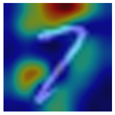

```python
import os
import cv2
conv_layer = model2.get_layer(index = 4)
fc_layer = model2.layers[6].get_weights()[0]

my_map = tf.matmul(conv_layer.output, fc_layer)
CAM = tf.keras.Model(inputs = model2.inputs, outputs = my_map)


idx = np.random.randint(val_i.shape[0])

pred = np.argmax(model2.predict(val_i[[idx]]))
predCAM = CAM.predict(val_i[[idx]])

attention = predCAM[:,:,:,pred]
attention = np.abs(np.reshape(attention, (7, 7)))
resized_attention = cv2.resize(attention,
                               (100, 100),
                               interpolation = cv2.INTER_CUBIC)
resized_image = cv2.resize(val_i[idx],
                           (100, 100),
                           interpolation = cv2.INTER_CUBIC)

print('pred: {} / true: {}'.format(pred, val_l[idx]))

plt.imshow(resized_image.reshape(100, 100), 'gray')
plt.imshow(resized_attention, 'jet', alpha = 0.5)
plt.axis('off')
plt.show()
```

```
pred: 1 / true: 1
```

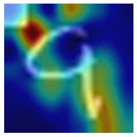

```python
import os
import cv2
conv_layer = model2.get_layer(index = 4)
fc_layer = model2.layers[6].get_weights()[0]

my_map = tf.matmul(conv_layer.output, fc_layer)
CAM = tf.keras.Model(inputs = model2.inputs, outputs = my_map)


idx = np.random.randint(val_i.shape[0])

pred = np.argmax(model2.predict(val_i[[idx]]))
predCAM = CAM.predict(val_i[[idx]])

attention = predCAM[:,:,:,pred]
attention = np.abs(np.reshape(attention, (7, 7)))
resized_attention = cv2.resize(attention,
                               (100, 100),
                               interpolation = cv2.INTER_CUBIC)
resized_image = cv2.resize(val_i[idx],
                           (100, 100),
                           interpolation = cv2.INTER_CUBIC)

print('pred: {} / true: {}'.format(pred, val_l[idx]))

plt.imshow(resized_image.reshape(100, 100), 'gray')
plt.imshow(resized_attention, 'jet', alpha = 0.5)
plt.axis('off')
plt.show()
```

5) With the information of the defects obtained in the section 4), fix the defects within the training data

- Hint 1: Change the pixel value of the defected region
- Hint 2: The defected region exists in only one of two classes and the locations of such defects are the same in all defected images
- Hint 3: Defect locations in the image matrix: (0,0), (0,1), (0,2), (0,3), (0,4), (1,0), (1,1), (1,2), (1,3), (1,4),(2,0), (2,1), (2,2), (2,3), (2,4), (3,0), (3,1), (3,2), (3,3), (3,4), (4,0), (4,1), (4,2), (4,3), (4,4)

```python
# Your code here
#
train_7 = train_img[np.where(train_label ==0)]
train_9 = train_img[np.where(train_label ==1)]
for i in range (0,5949):
    train_9[i,0,0]=0
    train_9[i,0,1]=0
    train_9[i,0,2]=0
    train_9[i,0,3]=0
    train_9[i,0,4]=0
    train_9[i,1,0]=0
    train_9[i,1,1]=0
    train_9[i,1,2]=0
    train_9[i,1,3]=0
    train_9[i,1,4]=0
    train_9[i,2,0]=0
    train_9[i,2,1]=0
    train_9[i,2,2]=0
    train_9[i,2,3]=0
    train_9[i,2,4]=0
    train_9[i,3,0]=0
    train_9[i,3,1]=0
    train_9[i,3,2]=0
    train_9[i,3,3]=0
    train_9[i,3,4]=0
    train_9[i,4,0]=0
    train_9[i,4,1]=0
    train_9[i,4,2]=0
    train_9[i,4,3]=0
    train_9[i,4,4]=0
    i=i+1
train_img=np.concatenate([train_7,train_9])
```

6) With the fixed training dataset obtained in the section 5), train the model you defined in the section 4) and report the test accuracy using the test dataset given in the section 3)  
If you have failed to fix the defects of the training data in the section 5), use MNIST data for this question.

```python
# Your code here
#
# Your code here
model3 = tf.keras.models.Sequential([
    tf.keras.layers.Conv2D(filters = 32,
                           kernel_size = (3,3),
                           activation = 'relu',
                           padding = 'SAME',
                           input_shape = (28, 28, 1)),

    tf.keras.layers.MaxPool2D((2,2)),

    tf.keras.layers.Conv2D(filters = 64,
                           kernel_size = (3,3),
                           activation = 'relu',
                           padding = 'SAME',
                           input_shape = (14, 14, 32)),

    tf.keras.layers.MaxPool2D((2,2)),

    tf.keras.layers.Conv2D(filters = 128,
                        kernel_size = (3,3),
                        activation = 'relu',
                        padding = 'SAME',
                        input_shape = (7, 7, 64)),

    tf.keras.layers.MaxPool2D((2,2)),

    tf.keras.layers.Flatten(),

    tf.keras.layers.Dense(units = 128, activation = 'relu'),

    tf.keras.layers.Dense(units = 2, activation = 'softmax')
])
```

```python
model3.compile(optimizer = 'adam',
              loss = 'sparse_categorical_crossentropy',
              metrics = ['accuracy'])
```

```python
model3.fit(train_img, train_label, epochs = 2, batch_size = 64)
```

```
Train on 12214 samples
```

```
<tensorflow.python.keras.callbacks.History at 0x197c6f749b0>
```

```python
results4 = model3.evaluate(test_i, test_l, batch_size=32)
print(results4)
```

```
[0.002800888197903606, 0.9991817]
```